# Example Datasets: Statsmodels

⇦ Back

The Statsmodels package [provides datasets](https://www.statsmodels.org/devel/datasets/) that can be used as example data in MWEs and ‘Hello World’ scripts that test functionality. These can be imported via the Statsmodels API and come as ‘modules’ inside the `datasets` object. Here’s how to list out all of the 28 datasets that are available:

```python
from statsmodels import api as sm

# List all 28 of the statsmodels datasets
print('Name               Title')
print('----               -----')
for attribute in dir(sm.datasets):
    # If the attribute is a module
    if str(type(getattr(sm.datasets, attribute))) == "<class 'module'>":
        # The utils module is not a dataset
        if attribute == 'utils':
            continue
        title = getattr(sm.datasets, attribute).TITLE
        print(f'{attribute:18s} {title}')
```

```
## Name               Title
## ----               -----
## anes96             American National Election Survey 1996
## cancer             Breast Cancer Data
## ccard              Bill Greene's credit scoring data.
## china_smoking      Smoking and lung cancer in eight cities in China.
## co2                Mauna Loa Weekly Atmospheric CO2 Data
## committee          First 100 days of the US House of Representatives 1995
## copper             World Copper Market 1951-1975 Dataset
## cpunish            US Capital Punishment dataset.
## danish_data        Danish Money Demand Data
## elnino             El Nino - Sea Surface Temperatures
## engel              Engel (1857) food expenditure data
## fair               Affairs dataset
## fertility          World Bank Fertility Data
## grunfeld           Grunfeld (1950) Investment Data
## heart              Transplant Survival Data
## interest_inflation (West) German interest and inflation rate 1972-1998
## longley            Longley dataset
## macrodata          United States Macroeconomic data
## modechoice         Travel Mode Choice
## nile               Nile River flows at Ashwan 1871-1970
## randhie            RAND Health Insurance Experiment Data
## scotland           Taxation Powers Vote for the Scottish Parliament 1997
## spector            Spector and Mazzeo (1980) - Program Effectiveness Data
## stackloss          Stack loss data
## star98             Star98 Educational Dataset
## statecrime         Statewide Crime Data 2009
## strikes            U.S. Strike Duration Data
## sunspots           Yearly sunspots data 1700-2008
```

Some more packages and settings that will be used by this page:

```python
from matplotlib import pyplot as plt
import pandas as pd
import numpy as np
from sklearn import linear_model
```

# American National Election Survey 1996

Documentation: https://www.statsmodels.org/devel/datasets/generated/anes96.html

**Exogenous Variables:**

- `logpopul` : `log(popul + .1)` where `popul` is census place population in 1000s
- `selfLR` : Respondent’s self-reported political leanings from “Left” to “Right”
- `age` : Age of respondent
- `educ` : Education level of respondent
- `income` : Income of household

**Endogenous Variable:**

- `PID` : Party identification of respondent

**Example Usage:**

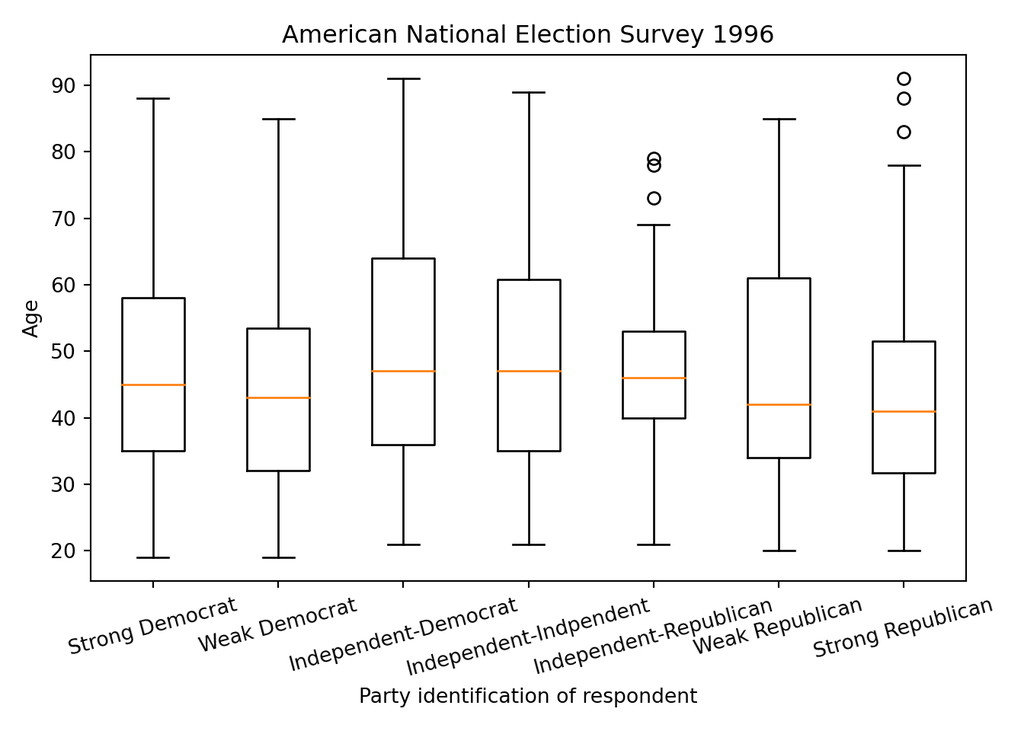

```python
# Load the data
dataset = sm.datasets.anes96.load_pandas()
X = dataset.exog
y = dataset.endog

# Plot
plt.title('American National Election Survey 1996')
df = pd.concat([X['age'], y], axis=1)
boxes = [df.loc[df['PID'] == val, 'age'] for val in df['PID'].unique()]
plt.boxplot(boxes)
plt.xlabel('Party identification of respondent')
plt.ylabel('Age')
identification = [
    'Strong Democrat', 'Weak Democrat', 'Independent-Democrat',
    'Independent-Indpendent', 'Independent-Republican', 'Weak Republican',
    'Strong Republican'
]
plt.xticks(ticks=range(1, 8), labels=identification, rotation=15)
plt.tight_layout()
plt.show()
```

# Breast Cancer Data

Documentation: https://www.statsmodels.org/devel/datasets/generated/cancer.html

**Exogenous Variable:**

- `population` : The population of the county

**Endogenous Variable:**

- `cancer` : The number of breast cancer observances

**Example Usage:**

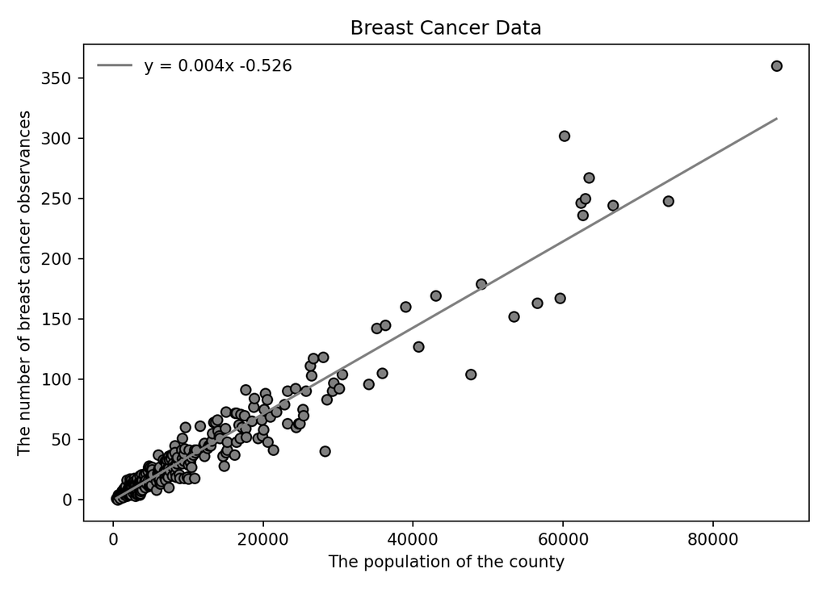

```python
# Load the data
dataset = sm.datasets.cancer.load_pandas()
X = dataset.exog
y = dataset.endog

# Create a linear regression model
model = linear_model.LinearRegression()
# Train the model
x = model.fit(X.values, y.values)

# Use the model to make a prediction
X_fitted = np.array([np.min(X), np.max(X)]).reshape(-1, 1)
y_fitted = model.predict(X_fitted)

# Plot
fig = plt.figure()
plt.title('Breast Cancer Data')
plt.scatter(X, y, ec='k', fc='gray')
label = f'y = {model.coef_[0]:.3f}x {model.intercept_:.3f}'
plt.plot(X_fitted, y_fitted, c='gray', label=label)
plt.xlabel('The population of the county')
plt.ylabel('The number of breast cancer observances')
plt.legend(frameon=False)
plt.tight_layout()
plt.show()
```

# Bill Greene’s Credit Scoring Data

Documentation: https://www.statsmodels.org/devel/datasets/generated/ccard.html

**Exogenous Variables:**

- `AGE` : Age in years+ 12ths of a year
- `INCOME` : Income, divided by 10,000
- `INCOMESQ` : `INCOME` squared
- `OWNRENT` : Individual owns (1) or rents (0) home

**Endogenous Variable:**

- `AVGEXP` : Avg monthly credit card expenditure

**Example Usage:**

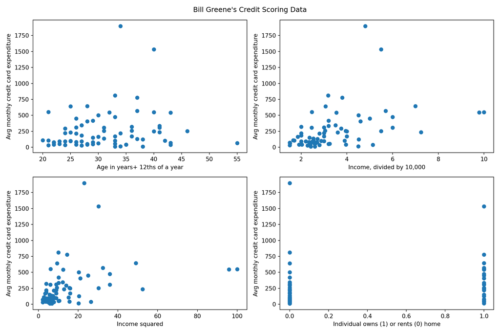

```python
# Load the data
dataset = sm.datasets.ccard.load_pandas()
X = dataset.exog
y = dataset.endog

# Plot
fig, ((ax1, ax2), (ax3, ax4)) = plt.subplots(2, 2, figsize=(12, 8))
fig.suptitle("Bill Greene's Credit Scoring Data")
ax1.scatter(X['AGE'], y)
ax1.set_xlabel('Age in years+ 12ths of a year')
ax1.set_ylabel('Avg monthly credit card expenditure')
ax2.scatter(X['INCOME'], y)
ax2.set_xlabel('Income, divided by 10,000')
ax2.set_ylabel('Avg monthly credit card expenditure')
ax3.scatter(X['INCOMESQ'], y)
ax3.set_xlabel('Income squared')
ax3.set_ylabel('Avg monthly credit card expenditure')
ax4.scatter(X['OWNRENT'], y)
ax4.set_xlabel('Individual owns (1) or rents (0) home')
ax4.set_ylabel('Avg monthly credit card expenditure')
plt.tight_layout()
plt.show()
```

# Smoking and Lung Cancer in Eight Cities in China

Documentation: https://www.statsmodels.org/devel/datasets/generated/china_smoking.html

**Variables:**

- `Location` : Name of the city
- `smoking` : Yes or no, according to a person’s smoking behavior
- `cancer` : Yes or no, according to a person’s lung cancer status

**Example Usage:**

```python
# Load the data
dataset = sm.datasets.china_smoking.load_pandas()
# Create contingency tables
contingency_tables = {}
for i, row in dataset['raw_data'].iterrows():
    dct = {
        'Cancer': [row['smoking_yes_cancer_yes'], row['smoking_no_cancer_yes']],
        'Healthy': [row['smoking_yes_cancer_no'], row['smoking_no_cancer_no']],
    }
    df = pd.DataFrame(dct, index=['Smoker', 'Non-Smoker'])
    contingency_tables[row['Location']] = df
    print(row['Location'] + ':')
    print(df)
    print('')
```

```
## Beijing:
##             Cancer  Healthy
## Smoker         126      100
## Non-Smoker      35       61
##
## Shanghai:
##             Cancer  Healthy
## Smoker         908      688
## Non-Smoker     497      807
##
## Shenyang:
##             Cancer  Healthy
## Smoker         913      747
## Non-Smoker     336      598
##
## Nanjng:
##             Cancer  Healthy
## Smoker         235      172
## Non-Smoker      58      121
##
## Harbin:
##             Cancer  Healthy
## Smoker         402      308
## Non-Smoker     121      215
##
## Zhengzhou:
##             Cancer  Healthy
## Smoker         182      156
## Non-Smoker      72       98
##
## Taiyuan:
##             Cancer  Healthy
## Smoker          60       99
## Non-Smoker      11       43
##
## Nanchang:
##             Cancer  Healthy
## Smoker         104       89
## Non-Smoker      21       36
```

# Mauna Loa Weekly Atmospheric CO2 Data

Documentation: https://www.statsmodels.org/devel/datasets/generated/co2.html

**Index:**

- `date` : Sample date in YYYY-MM-DD format. There is only one sample reported every 7 days as each represents a weekly average.

**Column:**

- `co2` : CO₂ concentration in ppmv (parts per million by volume)

**Example Usage:**

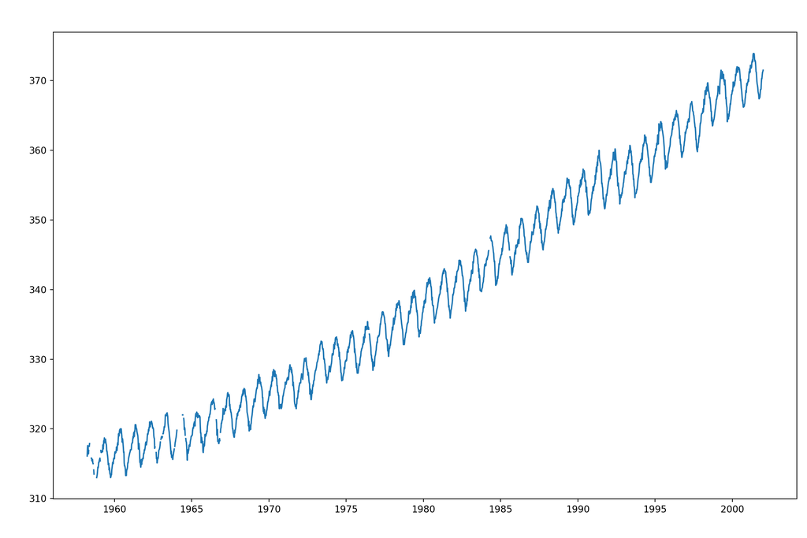

```python
# Load the data
dataset = sm.datasets.co2.load_pandas()
# Plot
plt.plot(dataset['data'])
plt.show()
```

# First 100 days of the US House of Representatives 1995

Documentation: https://www.statsmodels.org/devel/datasets/generated/committee.html

**Exogenous Variables:**

- `SIZE` : Number of members on the committee.
- `SUBS` : Number of subcommittees.
- `STAFF` : Number of staff members assigned to the committee.
- `PRESTIGE` : Dummy variable indicating whether the committee is a high prestige committee (`PRESTIGE == 1` is a high prestige committee).
- `BILLS103` : The number of bill assignments in the first 100 days of the US’s 103rd House of Representatives.

**Endogenous Variable:**

- `BILLS104` : The number of bill assignments in the first 100 days of the US’s 104th House of Representatives over 20 Committees.

**Example Usage:**

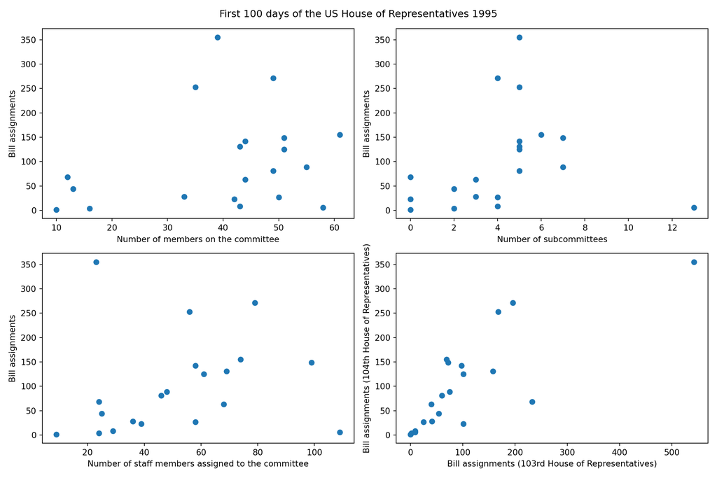

```python
# Load the data
dataset = sm.datasets.committee.load_pandas()
# Plot
fig, ((ax1, ax2), (ax3, ax4)) = plt.subplots(2, 2, figsize=(12, 8))
fig.suptitle('First 100 days of the US House of Representatives 1995')
ax1.scatter(dataset['exog']['SIZE'], dataset['endog'])
ax1.set_xlabel('Number of members on the committee')
ax1.set_ylabel('Bill assignments')
ax2.scatter(dataset['exog']['SUBS'], dataset['endog'])
ax2.set_xlabel('Number of subcommittees')
ax2.set_ylabel('Bill assignments')
ax3.scatter(dataset['exog']['STAFF'], dataset['endog'])
ax3.set_xlabel('Number of staff members assigned to the committee')
ax3.set_ylabel('Bill assignments')
ax4.scatter(dataset['exog']['BILLS103'], dataset['endog'])
ax4.set_xlabel('Bill assignments (103rd House of Representatives)')
ax4.set_ylabel('Bill assignments (104th House of Representatives)')
plt.tight_layout()
plt.show()
```

# World Copper Market 1951-1975 Dataset

Documentation: https://www.statsmodels.org/devel/datasets/generated/copper.html

**Exogenous Variables:**

- `COPPERPRICE` : Constant dollar adjusted price of copper.
- `INCOMEINDEX` : An index of real per capita income (base 1970).
- `ALUMPRICE` : The price of aluminium.
- `INVENTORYINDEX` : A measure of annual manufacturer inventory trend.
- `TIME` : A time trend.

**Endogenous Variable:**

- `WORLDCONSUMPTION` : World consumption of copper (in 1000 metric tons).

**Example Usage:**

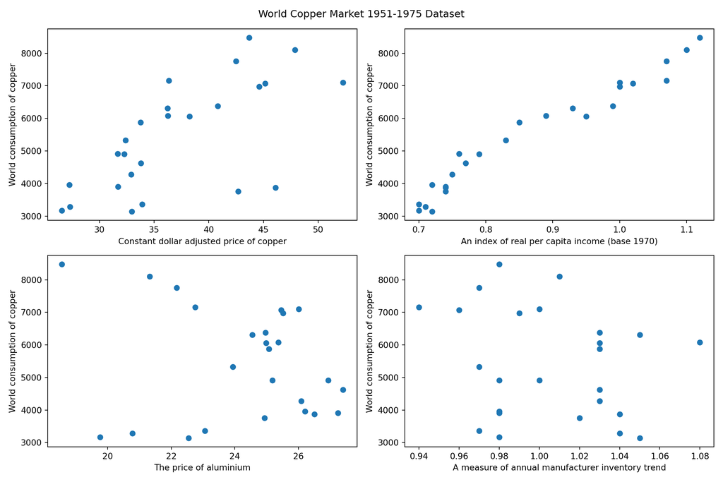

```python
# Load the data
dataset = sm.datasets.copper.load_pandas()
# Plot
fig, ((ax1, ax2), (ax3, ax4)) = plt.subplots(2, 2, figsize=(12, 8))
fig.suptitle('World Copper Market 1951-1975 Dataset')
ax1.scatter(dataset['exog']['COPPERPRICE'], dataset['endog'])
ax1.set_xlabel('Constant dollar adjusted price of copper')
ax1.set_ylabel('World consumption of copper')
ax2.scatter(dataset['exog']['INCOMEINDEX'], dataset['endog'])
ax2.set_xlabel('An index of real per capita income (base 1970)')
ax2.set_ylabel('World consumption of copper')
ax3.scatter(dataset['exog']['ALUMPRICE'], dataset['endog'])
ax3.set_xlabel('The price of aluminium')
ax3.set_ylabel('World consumption of copper')
ax4.scatter(dataset['exog']['INVENTORYINDEX'], dataset['endog'])
ax4.set_xlabel('A measure of annual manufacturer inventory trend')
ax4.set_ylabel('World consumption of copper')
plt.tight_layout()
plt.show()
```

# US Capital Punishment Dataset

Documentation: https://www.statsmodels.org/devel/datasets/generated/cpunish.html

**Exogenous Variables:**

- `INCOME` : Median per capita income in 1996 dollars
- `PERPOVERTY` : Percent of the population classified as living in poverty
- `PERBLACK` : Percent of black citizens in the population
- `VC100k96` : Rate of violent crimes per 100,00 residents for 1996
- `SOUTH` : `SOUTH == 1` indicates a state in the South
- `DEGREE` : An estimate of the proportion of the state population with a college degree of some kind

**Endogenous Variable:**

- `EXECUTIONS` : Executions in 1996

**Example Usage:**

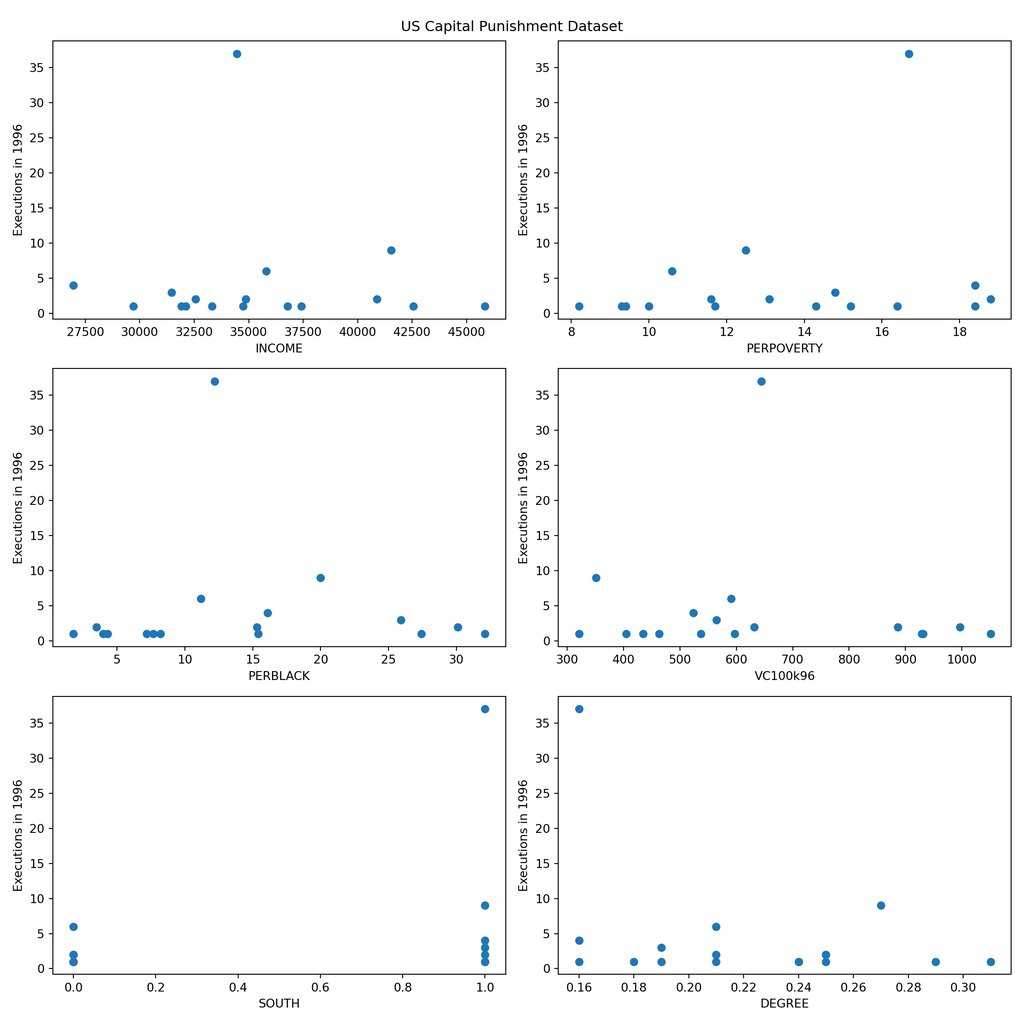

```python
# Load the data
dataset = sm.datasets.cpunish.load_pandas()
# Plot
fig, ax = plt.subplots(3, 2, figsize=(12, 12))
ax = ax.flatten()
fig.suptitle('US Capital Punishment Dataset')
for i, exog_name in enumerate(dataset['exog_name']):
    ax[i].scatter(dataset['exog'][exog_name], dataset['endog'])
    ax[i].set_xlabel(dataset['exog_name'][i])
    ax[i].set_ylabel('Executions in 1996')
plt.tight_layout()
plt.show()
```

⇦ Back